# QC Notes, Genomics Data

# Mapping indicators

### Basic mapping stats

Data from the aligner (`bowtie2`) log files. These are ordered by total number of paired end reads per timepoint.

| Timep | P.tot | P.1 | P.mul | P.dis | SE.1 | SE.mul | SE.0 | PE.0 | map.pe | map.se | Sample |
| --- | --- | --- | --- | --- | --- | --- | --- | --- | --- | --- | --- |
| P6005.PSM6XBSU_TR | 833 | 210 | 279 | 15 | 19 | 37 | 602 | 329 | 0.58703 | 0.085106 | P6005 |
| M2026.MSM6J2HB | 1496 | 262 | 306 | 12 | 20 | 34 | 1778 | 916 | 0.37968 | 0.029476 | M2026 |
| C3022.CSM7KOOR | 2258 | 256 | 490 | 12 | 17 | 71 | 2912 | 1500 | 0.33038 | 0.029333 | C3022 |
| H4018.HSM7J4LH | 2522 | 719 | 513 | 23 | 26 | 40 | 2468 | 1267 | 0.48850 | 0.026046 | H4018 |
| H4015.HSM7J4QJ | 8522 | 2445 | 1922 | 205 | 185 | 395 | 7320 | 3950 | 0.51244 | 0.073418 | H4015 |
| M2008.MSM5LLDU | 45690 | 16331 | 13183 | 2300 | 1209 | 4221 | 22322 | 13876 | 0.64596 | 0.195662 | M2008 |
| P6028.PSM7J177 | 136101 | 2611 | 2499 | 98 | 118 | 212 | 261456 | 130893 | 0.03755 | 0.001261 | P6028 |
| H4039.HSM7J4LP | 201473 | 10745 | 25379 | 427 | 559 | 2755 | 326530 | 164922 | 0.17930 | 0.010047 | H4039 |
| H4019.HSM7J4PK | 256241 | 29047 | 37284 | 1906 | 6202 | 6957 | 362849 | 188004 | 0.25886 | 0.034997 | H4019 |
| H4006.HSM5MD7O | 285604 | 27490 | 23925 | 2362 | 922 | 4120 | 458612 | 231827 | 0.18002 | 0.010874 | H4006 |

[output cut: 724 more lines]

In this table:

[output not shown]

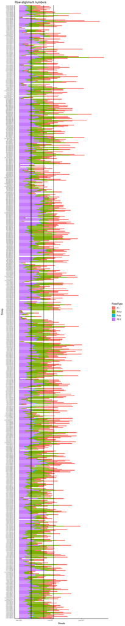

Mapping of metagenomics data is towards a sample-specific metagenomic reference containing all species ever identified for all time points of this individual.

### Summarised by individual

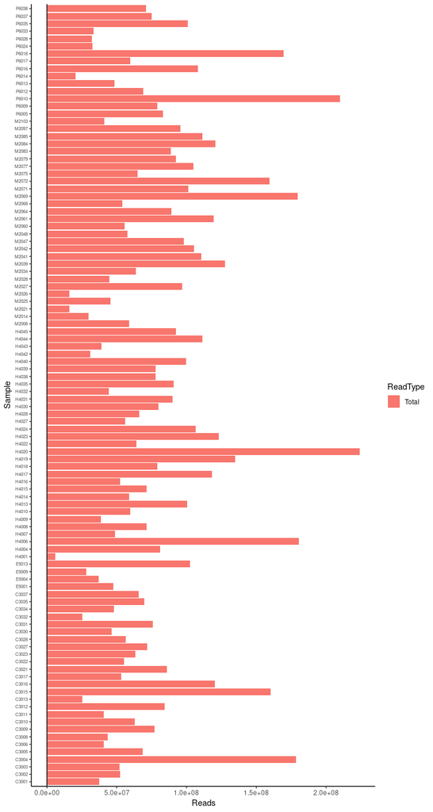

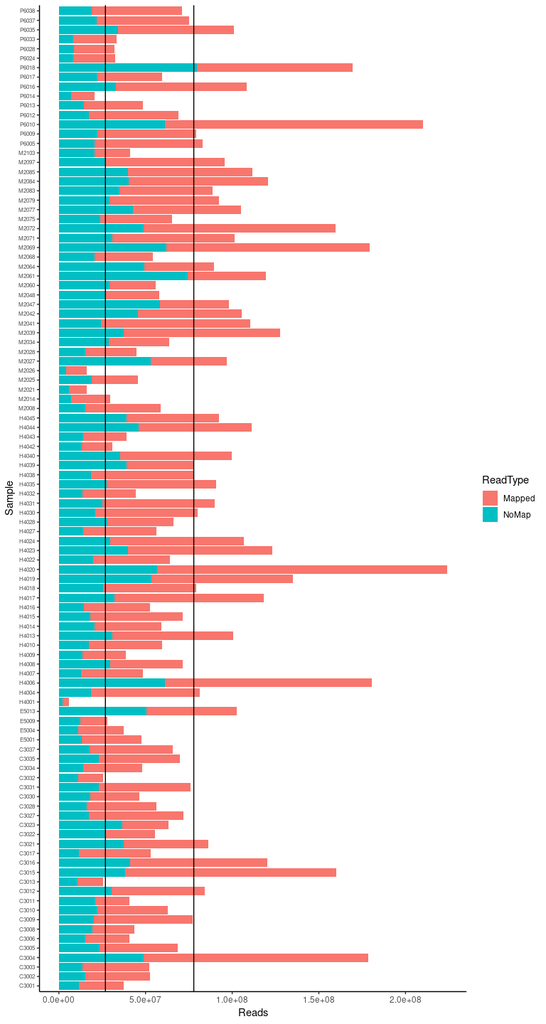

### Data from the feature counting (`subread featurecounts`)

(Uses data from BAM file, should be essentially same as previous)

This graph shows absolute number of mapped reads counted towards ORF / CDS at each timepoint for all individuals. The solid lines are the mean read counts across all.

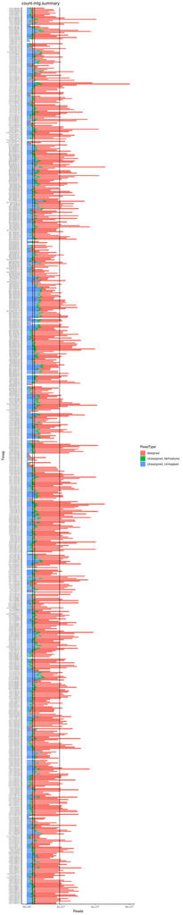

There are some individuals / timepoints with very low read counts overall.

The following graph shows the relative distribution of mapped reads (the non-plotted fraction to 100% are ambiguously mapped reads).

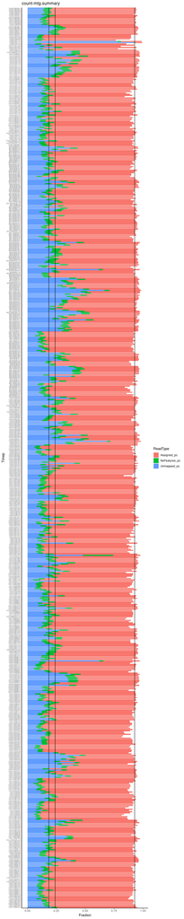

### Summary per individual

[output not shown]

Total number of mapped reads:

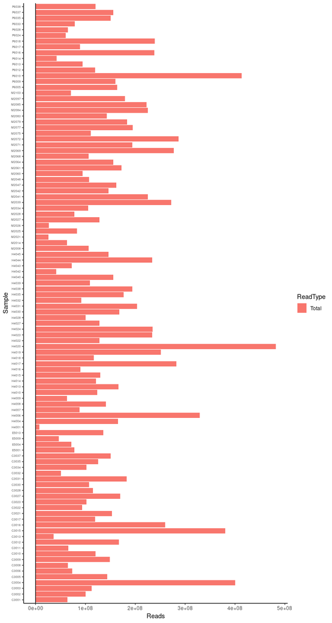

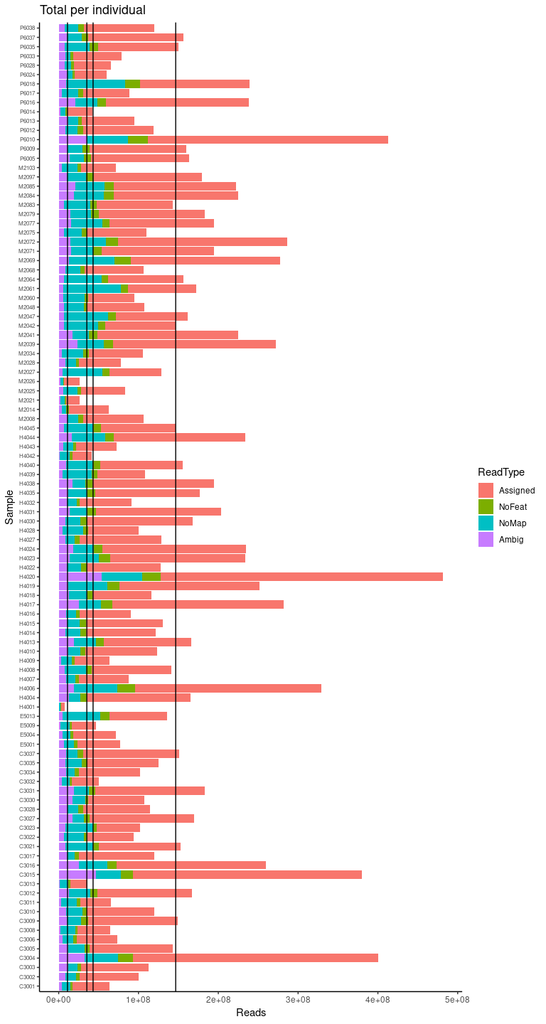

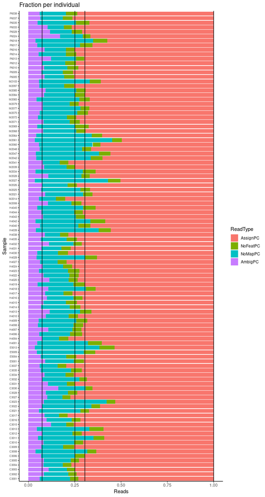

### Sample / Timepoint exclusion

The previous by-sample and by-timepoint results indicate some should be excluded even before going to the analysis of counts.

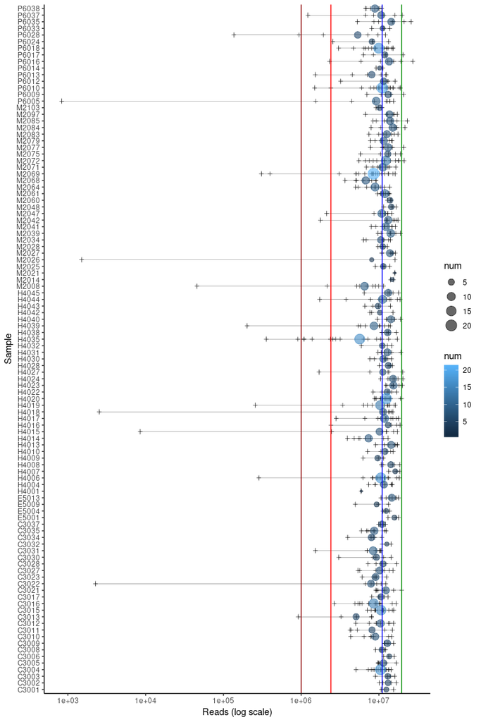

Reads scale is logarithmic to enhance the difference in the minimum total number of PE reads per timepoint for some individuals.  
The limits (coloured lines) correspond to 1MM reads (dark red), mean minus 2 standard dev (2.41MM reads, red), mean (11.03MM reads, blue) and mean plus 2 standard deviations (19.64MM reads, green). The bars extend from minimum number of reads per timepoint (of individual) to maximum. Dot is the mean number, size and color indicate number of timepoints.

The number of timepoints that would be excluded at each threshold is as follows (only the lower read count region shown). The low read count timepoints are the first rows of the table at the top of this document, but annotated here anyway.

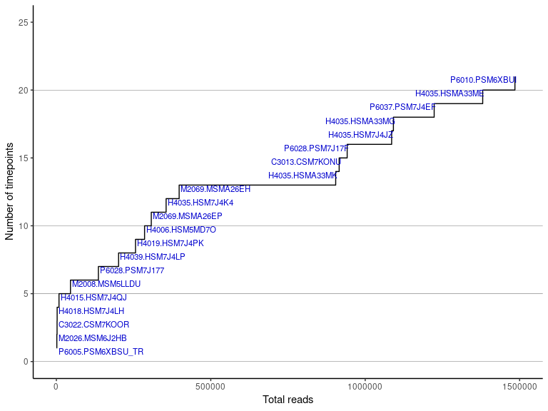

Consideration of the exclusion is deferred until the QC notes on transcriptomic is analysed.